# Regression Model for Superconductivity Temperature Using R Take 2

David Lowe

July 17, 2019

Template Credit: Adapted from a template made available by Dr. Jason Brownlee of Machine Learning Mastery. [http://machinelearningmastery.com/]

SUMMARY: The purpose of this project is to construct a prediction model using various machine learning algorithms and to document the end-to-end steps using a template. The Superconductivity Temperature dataset is a regression situation where we are trying to predict the value of a continuous variable.

INTRODUCTION: The research team wishes to create a statistical model for predicting the superconducting critical temperature based on the features extracted from the superconductor’s chemical formula. The model seeks to examine the features that can contribute the most to the model’s predictive accuracy.

In iteration Take1, we established the baseline mean squared error for comparison with the future rounds of modeling.

In this iteration, we will examine the feature selection technique of attribute importance ranking by using the Elasticnet algorithm. By selecting only the most important attributes, we hope to decrease the modeling time and still maintain a similar level of RMSE compared to the baseline.

ANALYSIS: The baseline performance of the machine learning algorithms achieved an average RMSE of 16.33. Two algorithms (Random Forest and Gradient Boosting) achieved the top RMSE metrics after the first round of modeling. After a series of tuning trials, Random Forest turned in the best overall result and achieved an RMSE metric of 9.72. By using the optimized parameters, the Random Forest algorithm processed the test dataset with an RMSE of 9.40, which was even better than the prediction from the training data.

From iteration Take2, the average performance of the machine learning algorithms achieved an RMSE of 16.40. Random Forest achieved an RMSE metric of 9.73 with the training dataset and processed the test dataset with an RMSE of 9.39. At the importance level of 99%, the attribute importance technique eliminated 10 of 81 total attributes. The remaining 71 attributes produced a model that achieved a comparable RMSE to the baseline model. The modeling time went from 6 hours 26 minutes down to 5 hours 50 minutes, a saving of 9.3%.

CONCLUSION: For this iteration, the Random Forest algorithm achieved the best overall results using the training and testing datasets. For this dataset, Random Forest should be considered for further modeling.

Dataset Used: Superconductivity Data Data Set

Dataset ML Model: Regression with numerical attributes

Dataset Reference: https://archive.ics.uci.edu/ml/datasets/Superconductivty+Data

One potential source of performance benchmarks: https://doi.org/10.1016/j.commatsci.2018.07.052

The project aims to touch on the following areas:

1. Document a predictive modeling problem end-to-end.
2. Explore data cleaning and transformation options
3. Explore non-ensemble and ensemble algorithms for baseline model performance
4. Explore algorithm tuning techniques for improving model performance

Any predictive modeling machine learning project genrally can be broken down into about six major tasks:

1. Prepare Problem
2. Summarize Data
3. Prepare Data
4. Model and Evaluate Algorithms
5. Improve Accuracy or Results
6. Finalize Model and Present Results

## 1. Prepare Problem

### 1.a) Load libraries

```r
startTimeScript <- proc.time()
library(caret)
```

```r
library(corrplot)
library(DMwR)
library(Hmisc)
library(mailR)
library(ROCR)
library(stringr)
```

```r
# Create one random seed number for reproducible results
seedNum <- 888
set.seed(seedNum)

# Set up the flag to send status emails (setting TRUE will send!)
notifyStatus <- TRUE
```

### 1.b) Set up the email notification function

```r
email_notify <- function(msg=""){
  sender <- Sys.getenv("MAIL_SENDER")
  receiver <- Sys.getenv("MAIL_RECEIVER")
  gateway <- Sys.getenv("SMTP_GATEWAY")
  smtpuser <- Sys.getenv("SMTP_USERNAME")
  password <- Sys.getenv("SMTP_PASSWORD")
  sbj_line <- "Notification from R Binary Classification Script"
  send.mail(
    from = sender,
    to = receiver,
    subject= sbj_line,
    body = msg,
    smtp = list(host.name = gateway, port = 587, user.name = smtpuser, passwd = password, ssl = TRUE),
    authenticate = TRUE,
    send = TRUE)
}
```

```r
if (notifyStatus) email_notify(paste("Library and Data Loading has begun!",date()))
```

```
## [1] "Java-Object{org.apache.commons.mail.SimpleEmail@5a39699c}"
```

### 1.c) Load dataset

```r
# Slicing up the document path to get the final destination file name
dataset_path <- 'https://archive.ics.uci.edu/ml/machine-learning-databases/00464/superconduct.zip'
doc_path_list <- str_split(dataset_path, "/")
dest_file <- doc_path_list[[1]][length(doc_path_list[[1]])]

if (!file.exists(dest_file)) {
  # Download the document from the website
  cat("Downloading", dataset_path, "as", dest_file, "\n")
  download.file(dataset_path, dest_file, mode = "wb")
  cat(dest_file, "downloaded!\n")
  unzip(dest_file)
  cat(dest_file, "unpacked!\n")
}

inputFile <- "train.csv"
xy_original <- read.csv(inputFile, header = TRUE, sep = ",")
```

```r
# Take a peek at the dataframe after the import
head(xy_original)
```

```
##   number_of_elements mean_atomic_mass wtd_mean_atomic_mass
## 1                  4         88.94447             57.86269
## 2                  5         92.72921             58.51842
## 3                  4         88.94447             57.88524
## 4                  4         88.94447             57.87397
## 5                  4         88.94447             57.84014
## 6                  4         88.94447             57.79504
##   gmean_atomic_mass wtd_gmean_atomic_mass entropy_atomic_mass
## 1          66.36159              36.11661            1.181795
## 2          73.13279              36.39660            1.449309
## 3          66.36159              36.12251            1.181795
## 4          66.36159              36.11956            1.181795
## 5          66.36159              36.11072            1.181795
## 6          66.36159              36.09893            1.181795
##   wtd_entropy_atomic_mass range_atomic_mass wtd_range_atomic_mass
```

[output cut: 167 more lines]

```r
sapply(xy_original, class)
```

```
##              number_of_elements                mean_atomic_mass
##                       "integer"                       "numeric"
##            wtd_mean_atomic_mass               gmean_atomic_mass
##                       "numeric"                       "numeric"
##           wtd_gmean_atomic_mass             entropy_atomic_mass
##                       "numeric"                       "numeric"
##         wtd_entropy_atomic_mass               range_atomic_mass
##                       "numeric"                       "numeric"
##           wtd_range_atomic_mass                 std_atomic_mass
##                       "numeric"                       "numeric"
##             wtd_std_atomic_mass                        mean_fie
##                       "numeric"                       "numeric"
##                    wtd_mean_fie                       gmean_fie
##                       "numeric"                       "numeric"
##                   wtd_gmean_fie                     entropy_fie
##                       "numeric"                       "numeric"
##                 wtd_entropy_fie                       range_fie
##                       "numeric"                       "numeric"
##                   wtd_range_fie                         std_fie
##                       "numeric"                       "numeric"
##                     wtd_std_fie              mean_atomic_radius
##                       "numeric"                       "numeric"
##          wtd_mean_atomic_radius             gmean_atomic_radius
##                       "numeric"                       "numeric"
##         wtd_gmean_atomic_radius           entropy_atomic_radius
##                       "numeric"                       "numeric"
##       wtd_entropy_atomic_radius             range_atomic_radius
##                       "numeric"                       "integer"
##         wtd_range_atomic_radius               std_atomic_radius
##                       "numeric"                       "numeric"
##           wtd_std_atomic_radius                    mean_Density
##                       "numeric"                       "numeric"
##                wtd_mean_Density                   gmean_Density
##                       "numeric"                       "numeric"
##               wtd_gmean_Density                 entropy_Density
##                       "numeric"                       "numeric"
##             wtd_entropy_Density                   range_Density
##                       "numeric"                       "numeric"
##               wtd_range_Density                     std_Density
##                       "numeric"                       "numeric"
```

[output cut: 27 more lines]

```
##                       "numeric"                       "numeric"
##   wtd_range_ThermalConductivity         std_ThermalConductivity
##                       "numeric"                       "numeric"
##     wtd_std_ThermalConductivity                    mean_Valence
##                       "numeric"                       "numeric"
##                wtd_mean_Valence                   gmean_Valence
##                       "numeric"                       "numeric"
##               wtd_gmean_Valence                 entropy_Valence
##                       "numeric"                       "numeric"
##             wtd_entropy_Valence                   range_Valence
##                       "numeric"                       "integer"
##               wtd_range_Valence                     std_Valence
##                       "numeric"                       "numeric"
##                 wtd_std_Valence                   critical_temp
##                       "numeric"                       "numeric"
```

```r
sapply(xy_original, function(x) sum(is.na(x)))
```

```
##              number_of_elements                mean_atomic_mass
##                               0                               0
##            wtd_mean_atomic_mass               gmean_atomic_mass
##                               0                               0
##           wtd_gmean_atomic_mass             entropy_atomic_mass
##                               0                               0
##         wtd_entropy_atomic_mass               range_atomic_mass
##                               0                               0
##           wtd_range_atomic_mass                 std_atomic_mass
##                               0                               0
##             wtd_std_atomic_mass                        mean_fie
##                               0                               0
##                    wtd_mean_fie                       gmean_fie
##                               0                               0
##                   wtd_gmean_fie                     entropy_fie
##                               0                               0
##                 wtd_entropy_fie                       range_fie
##                               0                               0
##                   wtd_range_fie                         std_fie
##                               0                               0
##                     wtd_std_fie              mean_atomic_radius
##                               0                               0
##          wtd_mean_atomic_radius             gmean_atomic_radius
##                               0                               0
##         wtd_gmean_atomic_radius           entropy_atomic_radius
##                               0                               0
##       wtd_entropy_atomic_radius             range_atomic_radius
##                               0                               0
##         wtd_range_atomic_radius               std_atomic_radius
##                               0                               0
##           wtd_std_atomic_radius                    mean_Density
##                               0                               0
##                wtd_mean_Density                   gmean_Density
##                               0                               0
##               wtd_gmean_Density                 entropy_Density
##                               0                               0
##             wtd_entropy_Density                   range_Density
##                               0                               0
##               wtd_range_Density                     std_Density
##                               0                               0
```

[output cut: 27 more lines]

```
##                               0                               0
##   wtd_range_ThermalConductivity         std_ThermalConductivity
##                               0                               0
##     wtd_std_ThermalConductivity                    mean_Valence
##                               0                               0
##                wtd_mean_Valence                   gmean_Valence
##                               0                               0
##               wtd_gmean_Valence                 entropy_Valence
##                               0                               0
##             wtd_entropy_Valence                   range_Valence
##                               0                               0
##               wtd_range_Valence                     std_Valence
##                               0                               0
##                 wtd_std_Valence                   critical_temp
##                               0                               0
```

### 1.d) Data Cleaning

```r
# Not applicable for this iteration of modeling
```

### 1.e) Splitting Data into Training and Testing Sets

```r
# Use variable totCol to hold the number of columns in the dataframe
totCol <- ncol(xy_original)

# Set up variable totAttr for the total number of attribute columns
totAttr <- totCol-1
```

```r
# targetCol variable indicates the column location of the target/class variable
# If the first column, set targetCol to 1. If the last column, set targetCol to totCol
# if (targetCol <> 1) and (targetCol <> totCol), be aware when slicing up the dataframes for visualization!
targetCol <- totCol

# Standardize the class column to the name of targetVar if applicable
colnames(xy_original)[targetCol] <- "targetVar"
```

```r
# We create various datasets (x_original, y_original) for various visualization and cleaning/transformation operations.
if (targetCol==1) {
x_original <- xy_original[,(targetCol+1):totCol]
y_original <- xy_original[,targetCol]
} else {
x_original <- xy_original[,1:(totAttr)]
y_original <- xy_original[,totCol]
}
```

### 1.f) Set up the key parameters to be used in the script

```r
# Set up the number of row and columns for visualization display. dispRow * dispCol should be >= totAttr
dispCol <- 4
if (totAttr%%dispCol == 0) {
dispRow <- totAttr%/%dispCol
} else {
dispRow <- (totAttr%/%dispCol) + 1
}
cat("Will attempt to create graphics grid (col x row): ", dispCol, ' by ', dispRow)
```

```
## Will attempt to create graphics grid (col x row):  4  by  21
```

```r
# Run algorithms using 10-fold cross validation
control <- trainControl(method="repeatedcv", number=10, repeats=1)
metricTarget <- "RMSE"
```

```r
if (notifyStatus) email_notify(paste("Library and Data Loading completed!",date()))
```

```
## [1] "Java-Object{org.apache.commons.mail.SimpleEmail@1cd072a9}"
```

## 2. Summarize Data

To gain a better understanding of the data that we have on-hand, we will leverage a number of descriptive statistics and data visualization techniques. The plan is to use the results to consider new questions, review assumptions, and validate hypotheses that we can investigate later with specialized models.

```r
if (notifyStatus) email_notify(paste("Data Summarization and Visualization has begun!",date()))
```

```
## [1] "Java-Object{org.apache.commons.mail.SimpleEmail@6a5fc7f7}"
```

### 2.a) Descriptive statistics

#### 2.a.i) Peek at the data itself.

```r
head(xy_original)
```

```
##   number_of_elements mean_atomic_mass wtd_mean_atomic_mass
## 1                  4         88.94447             57.86269
## 2                  5         92.72921             58.51842
## 3                  4         88.94447             57.88524
## 4                  4         88.94447             57.87397
## 5                  4         88.94447             57.84014
## 6                  4         88.94447             57.79504
##   gmean_atomic_mass wtd_gmean_atomic_mass entropy_atomic_mass
## 1          66.36159              36.11661            1.181795
## 2          73.13279              36.39660            1.449309
## 3          66.36159              36.12251            1.181795
## 4          66.36159              36.11956            1.181795
## 5          66.36159              36.11072            1.181795
## 6          66.36159              36.09893            1.181795
##   wtd_entropy_atomic_mass range_atomic_mass wtd_range_atomic_mass
```

[output cut: 167 more lines]

#### 2.a.ii) Dimensions of the dataset.

```r
dim(xy_original)
```

```
## [1] 21263    82
```

#### 2.a.iii) Types of the attributes.

```r
sapply(xy_original, class)
```

```
##              number_of_elements                mean_atomic_mass
##                       "integer"                       "numeric"
##            wtd_mean_atomic_mass               gmean_atomic_mass
##                       "numeric"                       "numeric"
##           wtd_gmean_atomic_mass             entropy_atomic_mass
##                       "numeric"                       "numeric"
##         wtd_entropy_atomic_mass               range_atomic_mass
##                       "numeric"                       "numeric"
##           wtd_range_atomic_mass                 std_atomic_mass
##                       "numeric"                       "numeric"
##             wtd_std_atomic_mass                        mean_fie
##                       "numeric"                       "numeric"
##                    wtd_mean_fie                       gmean_fie
##                       "numeric"                       "numeric"
##                   wtd_gmean_fie                     entropy_fie
##                       "numeric"                       "numeric"
##                 wtd_entropy_fie                       range_fie
##                       "numeric"                       "numeric"
##                   wtd_range_fie                         std_fie
##                       "numeric"                       "numeric"
##                     wtd_std_fie              mean_atomic_radius
##                       "numeric"                       "numeric"
##          wtd_mean_atomic_radius             gmean_atomic_radius
##                       "numeric"                       "numeric"
##         wtd_gmean_atomic_radius           entropy_atomic_radius
##                       "numeric"                       "numeric"
##       wtd_entropy_atomic_radius             range_atomic_radius
##                       "numeric"                       "integer"
##         wtd_range_atomic_radius               std_atomic_radius
##                       "numeric"                       "numeric"
##           wtd_std_atomic_radius                    mean_Density
##                       "numeric"                       "numeric"
##                wtd_mean_Density                   gmean_Density
##                       "numeric"                       "numeric"
##               wtd_gmean_Density                 entropy_Density
##                       "numeric"                       "numeric"
##             wtd_entropy_Density                   range_Density
##                       "numeric"                       "numeric"
##               wtd_range_Density                     std_Density
##                       "numeric"                       "numeric"
```

[output cut: 27 more lines]

```
##                       "numeric"                       "numeric"
##   wtd_range_ThermalConductivity         std_ThermalConductivity
##                       "numeric"                       "numeric"
##     wtd_std_ThermalConductivity                    mean_Valence
##                       "numeric"                       "numeric"
##                wtd_mean_Valence                   gmean_Valence
##                       "numeric"                       "numeric"
##               wtd_gmean_Valence                 entropy_Valence
##                       "numeric"                       "numeric"
##             wtd_entropy_Valence                   range_Valence
##                       "numeric"                       "integer"
##               wtd_range_Valence                     std_Valence
##                       "numeric"                       "numeric"
##                 wtd_std_Valence                       targetVar
##                       "numeric"                       "numeric"
```

#### 2.a.iv) Statistical summary of all attributes.

```r
summary(xy_original)
```

```
##  number_of_elements mean_atomic_mass  wtd_mean_atomic_mass
##  Min.   :1.000      Min.   :  6.941   Min.   :  6.423
##  1st Qu.:3.000      1st Qu.: 72.458   1st Qu.: 52.144
##  Median :4.000      Median : 84.923   Median : 60.697
##  Mean   :4.115      Mean   : 87.558   Mean   : 72.988
##  3rd Qu.:5.000      3rd Qu.:100.404   3rd Qu.: 86.104
##  Max.   :9.000      Max.   :208.980   Max.   :208.980
##  gmean_atomic_mass wtd_gmean_atomic_mass entropy_atomic_mass
##  Min.   :  5.321   Min.   :  1.961       Min.   :0.0000
##  1st Qu.: 58.041   1st Qu.: 35.249       1st Qu.:0.9667
##  Median : 66.362   Median : 39.918       Median :1.1995
##  Mean   : 71.291   Mean   : 58.540       Mean   :1.1656
##  3rd Qu.: 78.117   3rd Qu.: 73.113       3rd Qu.:1.4445
##  Max.   :208.980   Max.   :208.980       Max.   :1.9838
##  wtd_entropy_atomic_mass range_atomic_mass wtd_range_atomic_mass
##  Min.   :0.0000          Min.   :  0.00    Min.   :  0.00
##  1st Qu.:0.7754          1st Qu.: 78.51    1st Qu.: 16.82
##  Median :1.1468          Median :122.91    Median : 26.64
##  Mean   :1.0639          Mean   :115.60    Mean   : 33.23
##  3rd Qu.:1.3594          3rd Qu.:154.12    3rd Qu.: 38.36
##  Max.   :1.9582          Max.   :207.97    Max.   :205.59
##  std_atomic_mass  wtd_std_atomic_mass    mean_fie       wtd_mean_fie
##  Min.   :  0.00   Min.   :  0.00      Min.   : 375.5   Min.   : 375.5
##  1st Qu.: 32.89   1st Qu.: 28.54      1st Qu.: 723.7   1st Qu.: 738.9
##  Median : 45.12   Median : 44.29      Median : 764.9   Median : 890.0
##  Mean   : 44.39   Mean   : 41.45      Mean   : 769.6   Mean   : 870.4
##  3rd Qu.: 59.32   3rd Qu.: 53.63      3rd Qu.: 796.3   3rd Qu.:1004.1
##  Max.   :101.02   Max.   :101.02      Max.   :1313.1   Max.   :1348.0
##    gmean_fie      wtd_gmean_fie     entropy_fie    wtd_entropy_fie
##  Min.   : 375.5   Min.   : 375.5   Min.   :0.000   Min.   :0.0000
##  1st Qu.: 692.5   1st Qu.: 720.1   1st Qu.:1.086   1st Qu.:0.7538
##  Median : 728.0   Median : 856.2   Median :1.356   Median :0.9168
##  Mean   : 737.5   Mean   : 832.8   Mean   :1.299   Mean   :0.9267
##  3rd Qu.: 765.7   3rd Qu.: 937.6   3rd Qu.:1.551   3rd Qu.:1.0618
##  Max.   :1313.1   Max.   :1327.6   Max.   :2.158   Max.   :2.0386
##    range_fie      wtd_range_fie       std_fie       wtd_std_fie
##  Min.   :   0.0   Min.   :   0.0   Min.   :  0.0   Min.   :  0.00
##  1st Qu.: 262.4   1st Qu.: 291.1   1st Qu.:114.1   1st Qu.: 92.99
##  Median : 764.1   Median : 510.4   Median :266.4   Median :258.45
##  Mean   : 572.2   Mean   : 483.5   Mean   :215.6   Mean   :224.05
```

[output cut: 141 more lines]

```
##  Max.   :7.000   Max.   :7.000     Max.   :2.142   Max.   :1.9497
##  range_Valence   wtd_range_Valence  std_Valence     wtd_std_Valence
##  Min.   :0.000   Min.   :0.0000    Min.   :0.0000   Min.   :0.0000
##  1st Qu.:1.000   1st Qu.:0.9215    1st Qu.:0.4518   1st Qu.:0.3069
##  Median :2.000   Median :1.0631    Median :0.8000   Median :0.5000
##  Mean   :2.041   Mean   :1.4830    Mean   :0.8393   Mean   :0.6740
##  3rd Qu.:3.000   3rd Qu.:1.9184    3rd Qu.:1.2000   3rd Qu.:1.0204
##  Max.   :6.000   Max.   :6.9922    Max.   :3.0000   Max.   :3.0000
##    targetVar
##  Min.   :  0.00021
##  1st Qu.:  5.36500
##  Median : 20.00000
##  Mean   : 34.42122
##  3rd Qu.: 63.00000
##  Max.   :185.00000
```

#### 2.a.v) Count missing values.

```r
sapply(xy_original, function(x) sum(is.na(x)))
```

```
##              number_of_elements                mean_atomic_mass
##                               0                               0
##            wtd_mean_atomic_mass               gmean_atomic_mass
##                               0                               0
##           wtd_gmean_atomic_mass             entropy_atomic_mass
##                               0                               0
##         wtd_entropy_atomic_mass               range_atomic_mass
##                               0                               0
##           wtd_range_atomic_mass                 std_atomic_mass
##                               0                               0
##             wtd_std_atomic_mass                        mean_fie
##                               0                               0
##                    wtd_mean_fie                       gmean_fie
##                               0                               0
##                   wtd_gmean_fie                     entropy_fie
##                               0                               0
##                 wtd_entropy_fie                       range_fie
##                               0                               0
##                   wtd_range_fie                         std_fie
##                               0                               0
##                     wtd_std_fie              mean_atomic_radius
##                               0                               0
##          wtd_mean_atomic_radius             gmean_atomic_radius
##                               0                               0
##         wtd_gmean_atomic_radius           entropy_atomic_radius
##                               0                               0
##       wtd_entropy_atomic_radius             range_atomic_radius
##                               0                               0
##         wtd_range_atomic_radius               std_atomic_radius
##                               0                               0
##           wtd_std_atomic_radius                    mean_Density
##                               0                               0
##                wtd_mean_Density                   gmean_Density
##                               0                               0
##               wtd_gmean_Density                 entropy_Density
##                               0                               0
##             wtd_entropy_Density                   range_Density
##                               0                               0
##               wtd_range_Density                     std_Density
##                               0                               0
```

[output cut: 27 more lines]

```
##                               0                               0
##   wtd_range_ThermalConductivity         std_ThermalConductivity
##                               0                               0
##     wtd_std_ThermalConductivity                    mean_Valence
##                               0                               0
##                wtd_mean_Valence                   gmean_Valence
##                               0                               0
##               wtd_gmean_Valence                 entropy_Valence
##                               0                               0
##             wtd_entropy_Valence                   range_Valence
##                               0                               0
##               wtd_range_Valence                     std_Valence
##                               0                               0
##                 wtd_std_Valence                       targetVar
##                               0                               0
```

### 2.b) Data visualizations

```r
# Boxplots for each attribute
# par(mfrow=c(dispRow,dispCol))
# for(i in 1:totAttr) {
#   boxplot(x_original[,i], main=names(x_original)[i])
# }
```

```r
# Histograms each attribute
# par(mfrow=c(dispRow,dispCol))
# for(i in 1:totAttr) {
#   hist(x_original[,i], main=names(x_original)[i])
# }
```

```r
# Density plot for each attribute
# par(mfrow=c(dispRow,dispCol))
# for(i in 1:totAttr) {
#   plot(density(x_original[,i]), main=names(x_original)[i])
# }
```

```r
# Correlation plot
# correlations <- cor(x_original)
# corrplot(correlations, method="circle")
```

```r
if (notifyStatus) email_notify(paste("Data Summarization and Visualization completed!",date()))
```

```
## [1] "Java-Object{org.apache.commons.mail.SimpleEmail@511baa65}"
```

## 3. Prepare Data

Some dataset may require additional preparation activities that will best exposes the structure of the problem and the relationships between the input attributes and the output variable. Some data-prep tasks might include:

- Cleaning data by removing duplicates, marking missing values and even imputing missing values.
- Feature selection where redundant features may be removed.
- Data transforms where attributes are scaled or redistributed in order to best expose the structure of the problem later to learning algorithms.

```r
if (notifyStatus) email_notify(paste("Data Cleaning and Transformation has begun!",date()))
```

```
## [1] "Java-Object{org.apache.commons.mail.SimpleEmail@6fadae5d}"
```

### 3.a) Split Original Dataset into Training and Test

```r
# Create a list of the rows in the original dataset we can use for training
# Use 70% of the data to train the models and the remaining for testing/validation
set.seed(seedNum)
training_index <- createDataPartition(xy_original$targetVar, p=0.70, list=FALSE)
xy_train <- xy_original[training_index,]
xy_test <- xy_original[-training_index,]

totCol <- ncol(xy_original)
targetCol <- totCol
if (targetCol==1) {
y_test <- xy_test[,targetCol]
} else {
y_test <- xy_test[,totCol]
}
```

### 3.b) Feature Selection

```r
# Sample code for performing feature selection by ranking the attributes' importance.
startTimeModule <- proc.time()
set.seed(seedNum)
model_fs <- train(targetVar~., data=xy_train, method="enet", preProcess="scale", trControl=control)
rankedImportance <- varImp(model_fs, scale=FALSE)
print(rankedImportance)
```

```
## loess r-squared variable importance
##
##   only 20 most important variables shown (out of 81)
##
##                               Overall
## wtd_std_ThermalConductivity    0.5451
## wtd_mean_Valence               0.5046
## wtd_gmean_Valence              0.5024
## wtd_entropy_atomic_mass        0.4850
## range_ThermalConductivity      0.4703
## wtd_entropy_Valence            0.4480
## wtd_entropy_atomic_radius      0.4437
## range_atomic_radius            0.4263
## std_ThermalConductivity        0.4242
## wtd_std_atomic_radius          0.3878
## wtd_entropy_FusionHeat         0.3867
## wtd_std_fie                    0.3842
## wtd_gmean_Density              0.3729
## wtd_range_Valence              0.3707
## number_of_elements             0.3598
## mean_Valence                   0.3587
## entropy_Valence                0.3581
## range_fie                      0.3562
## wtd_range_ThermalConductivity  0.3544
## wtd_std_ElectronAffinity       0.3434
```

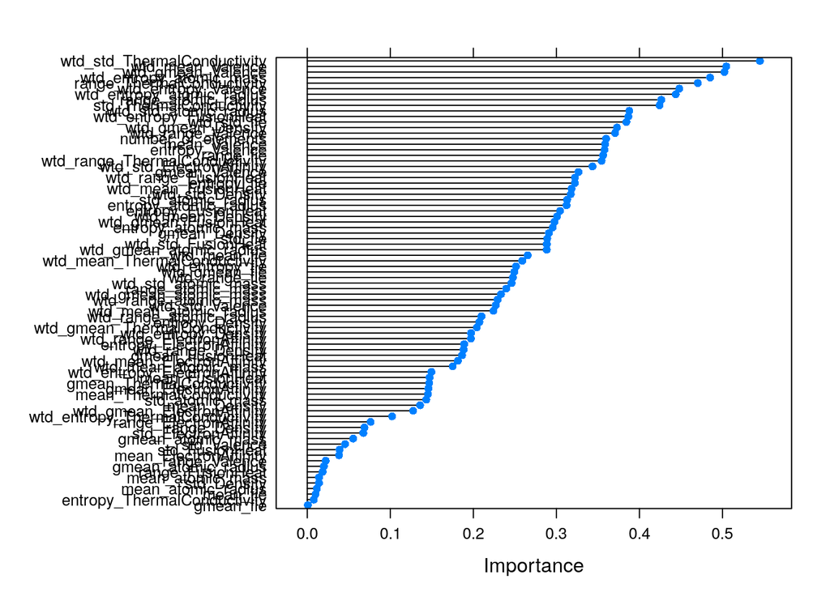

```r
plot(rankedImportance)
```

```r
# Set the importance threshold and calculate the list of attributes that don't contribute to the importance threshold
maxThreshold <- 0.99
rankedAttributes <- rankedImportance$importance
rankedAttributes <- rankedAttributes[order(-rankedAttributes$Overall),,drop=FALSE]
totalWeight <- sum(rankedAttributes)
i <- 1
accumWeight <- 0
exit_now <- FALSE
while ((i <= totAttr) & !exit_now) {
  accumWeight = accumWeight + rankedAttributes[i,]
  if ((accumWeight/totalWeight) >= maxThreshold) {
    exit_now <- TRUE
  } else {
    i <- i + 1
  }
}
lowImportance <- rankedAttributes[(i+1):(totAttr),,drop=FALSE]
lowAttributes <- rownames(lowImportance)
cat('Number of attributes contributed to the importance threshold:',i,"\n")
```

```
## Number of attributes contributed to the importance threshold: 71
```

```r
cat('Number of attributes found to be of low importance:',length(lowAttributes))
```

```
## Number of attributes found to be of low importance: 10
```

```r
# Removing the unselected attributes from the training and validation dataframes
xy_train <- xy_train[, !(names(xy_train) %in% lowAttributes)]
xy_test <- xy_test[, !(names(xy_test) %in% lowAttributes)]
```

### 3.c) Data Transforms

```r
# Not applicable for this iteration of modeling
```

### 3.d) Display the Final Dataset for Model-Building

```r
dim(xy_train)
```

```
## [1] 14886    72
```

```r
dim(xy_test)
```

```
## [1] 6377   72
```

```r
sapply(xy_train, class)
```

```
##              number_of_elements            wtd_mean_atomic_mass
##                       "integer"                       "numeric"
##               gmean_atomic_mass           wtd_gmean_atomic_mass
##                       "numeric"                       "numeric"
##             entropy_atomic_mass         wtd_entropy_atomic_mass
##                       "numeric"                       "numeric"
##               range_atomic_mass           wtd_range_atomic_mass
##                       "numeric"                       "numeric"
##                 std_atomic_mass             wtd_std_atomic_mass
##                       "numeric"                       "numeric"
##                    wtd_mean_fie                   wtd_gmean_fie
##                       "numeric"                       "numeric"
##                     entropy_fie                 wtd_entropy_fie
##                       "numeric"                       "numeric"
##                       range_fie                   wtd_range_fie
##                       "numeric"                       "numeric"
##                         std_fie                     wtd_std_fie
##                       "numeric"                       "numeric"
##          wtd_mean_atomic_radius         wtd_gmean_atomic_radius
##                       "numeric"                       "numeric"
##           entropy_atomic_radius       wtd_entropy_atomic_radius
##                       "numeric"                       "numeric"
##             range_atomic_radius         wtd_range_atomic_radius
##                       "integer"                       "numeric"
##               std_atomic_radius           wtd_std_atomic_radius
##                       "numeric"                       "numeric"
##                    mean_Density                wtd_mean_Density
##                       "numeric"                       "numeric"
##                   gmean_Density               wtd_gmean_Density
##                       "numeric"                       "numeric"
##                 entropy_Density             wtd_entropy_Density
##                       "numeric"                       "numeric"
##                   range_Density               wtd_range_Density
##                       "numeric"                       "numeric"
##                 wtd_std_Density       wtd_mean_ElectronAffinity
##                       "numeric"                       "numeric"
##          gmean_ElectronAffinity      wtd_gmean_ElectronAffinity
##                       "numeric"                       "numeric"
##        entropy_ElectronAffinity    wtd_entropy_ElectronAffinity
##                       "numeric"                       "numeric"
```

[output cut: 17 more lines]

```
##                       "numeric"                       "numeric"
##       range_ThermalConductivity   wtd_range_ThermalConductivity
##                       "numeric"                       "numeric"
##         std_ThermalConductivity     wtd_std_ThermalConductivity
##                       "numeric"                       "numeric"
##                    mean_Valence                wtd_mean_Valence
##                       "numeric"                       "numeric"
##                   gmean_Valence               wtd_gmean_Valence
##                       "numeric"                       "numeric"
##                 entropy_Valence             wtd_entropy_Valence
##                       "numeric"                       "numeric"
##               wtd_range_Valence                     std_Valence
##                       "numeric"                       "numeric"
##                 wtd_std_Valence                       targetVar
##                       "numeric"                       "numeric"
```

```r
if (notifyStatus) email_notify(paste("Data Cleaning and Transformation completed!",date()))
```

```
## [1] "Java-Object{org.apache.commons.mail.SimpleEmail@35f983a6}"
```

```r
proc.time()-startTimeScript
```

```
##    user  system elapsed
## 140.481  90.205 133.618
```

## 4. Model and Evaluate Algorithms

After the data-prep, we next work on finding a workable model by evaluating a subset of machine learning algorithms that are good at exploiting the structure of the dataset. The typical evaluation tasks include:

- Defining test options such as cross validation and the evaluation metric to use.
- Spot checking a suite of linear and nonlinear machine learning algorithms.
- Comparing the estimated accuracy of algorithms.

For this project, we will evaluate four linear, one non-linear, and three ensemble algorithms:

Linear Algorithm: Linear Regression, Ridge, The Lasso, Elasticnet

Non-Linear Algorithm: Decision Trees (CART)

Ensemble Algorithms: Bagged CART, Random Forest, and Gradient Boosting

The random number seed is reset before each run to ensure that the evaluation of each algorithm is performed using the same data splits. It ensures the results are directly comparable.

### 4.a) Generate models using linear algorithms

```r
startModeling <- proc.time()
```

```r
# Linear Regression (Regression)
if (notifyStatus) email_notify(paste("Linear Regression modeling has begun!",date()))
```

```
## [1] "Java-Object{org.apache.commons.mail.SimpleEmail@3498ed}"
```

```r
startTimeModule <- proc.time()
set.seed(seedNum)
fit.lm <- train(targetVar~., data=xy_train, method="lm", metric=metricTarget, trControl=control)
print(fit.lm)
```

```
## Linear Regression
##
## 14886 samples
##    71 predictor
##
## No pre-processing
## Resampling: Cross-Validated (10 fold, repeated 1 times)
## Summary of sample sizes: 13397, 13398, 13397, 13397, 13397, 13398, ...
## Resampling results:
##
##   RMSE      Rsquared   MAE
##   17.80942  0.7292765  13.48285
##
## Tuning parameter 'intercept' was held constant at a value of TRUE
```

```r
proc.time()-startTimeModule
```

```
##    user  system elapsed
##   3.005   1.766   2.962
```

```r
if (notifyStatus) email_notify(paste("Linear Regression modeling completed!",date()))
```

```
## [1] "Java-Object{org.apache.commons.mail.SimpleEmail@38082d64}"
```

```r
# Ridge (Regression)
if (notifyStatus) email_notify(paste("Ridge Regression modeling has begun!",date()))
```

```
## [1] "Java-Object{org.apache.commons.mail.SimpleEmail@180bc464}"
```

```r
startTimeModule <- proc.time()
set.seed(seedNum)
fit.ridge <- train(targetVar~., data=xy_train, method="ridge", metric=metricTarget, trControl=control)
print(fit.ridge)
```

```
## Ridge Regression
##
## 14886 samples
##    71 predictor
##
## No pre-processing
## Resampling: Cross-Validated (10 fold, repeated 1 times)
## Summary of sample sizes: 13397, 13398, 13397, 13397, 13397, 13398, ...
## Resampling results across tuning parameters:
##
##   lambda  RMSE      Rsquared   MAE
##   0e+00   17.80942  0.7292765  13.48285
##   1e-04   17.81118  0.7292209  13.48907
##   1e-01   19.25529  0.6854782  14.96340
##
## RMSE was used to select the optimal model using the smallest value.
## The final value used for the model was lambda = 0.
```

```r
proc.time()-startTimeModule
```

```
##    user  system elapsed
##  39.987  27.732  35.622
```

```r
if (notifyStatus) email_notify(paste("Ridge Regression modeling completed!",date()))
```

```
## [1] "Java-Object{org.apache.commons.mail.SimpleEmail@614c5515}"
```

```r
# The Lasso (Regression)
if (notifyStatus) email_notify(paste("The Lasso modeling has begun!",date()))
```

```
## [1] "Java-Object{org.apache.commons.mail.SimpleEmail@1936f0f5}"
```

```r
startTimeModule <- proc.time()
set.seed(seedNum)
fit.lasso <- train(targetVar~., data=xy_train, method="lasso", metric=metricTarget, trControl=control)
print(fit.lasso)
```

```
## The lasso
##
## 14886 samples
##    71 predictor
##
## No pre-processing
## Resampling: Cross-Validated (10 fold, repeated 1 times)
## Summary of sample sizes: 13397, 13398, 13397, 13397, 13397, 13398, ...
## Resampling results across tuning parameters:
##
##   fraction  RMSE      Rsquared   MAE
##   0.1       19.33433  0.6819751  14.92547
##   0.5       17.93642  0.7254614  13.59462
##   0.9       17.80949  0.7292731  13.47892
##
## RMSE was used to select the optimal model using the smallest value.
## The final value used for the model was fraction = 0.9.
```

```r
proc.time()-startTimeModule
```

```
##    user  system elapsed
##  15.264  10.630  13.649
```

```r
if (notifyStatus) email_notify(paste("The Lasso modeling completed!",date()))
```

```
## [1] "Java-Object{org.apache.commons.mail.SimpleEmail@35fb3008}"
```

```r
# Elasticnet (Regression)
if (notifyStatus) email_notify(paste("Elasticnet modeling has begun!",date()))
```

```
## [1] "Java-Object{org.apache.commons.mail.SimpleEmail@737996a0}"
```

```r
startTimeModule <- proc.time()
set.seed(seedNum)
fit.enet <- train(targetVar~., data=xy_train, method="enet", metric=metricTarget, trControl=control)
print(fit.enet)
```

```
## Elasticnet
##
## 14886 samples
##    71 predictor
##
## No pre-processing
## Resampling: Cross-Validated (10 fold, repeated 1 times)
## Summary of sample sizes: 13397, 13398, 13397, 13397, 13397, 13398, ...
## Resampling results across tuning parameters:
##
##   lambda  fraction  RMSE      Rsquared   MAE
##   0e+00   0.050     20.84443  0.6338134  16.22657
##   0e+00   0.525     17.91537  0.7260960  13.57305
##   0e+00   1.000     17.80942  0.7292765  13.48285
##   1e-04   0.050     21.26772  0.6215796  16.55688
##   1e-04   0.525     17.98110  0.7241086  13.64190
##   1e-04   1.000     17.81118  0.7292209  13.48907
##   1e-01   0.050     29.93294  0.5173865  25.25724
##   1e-01   0.525     19.93161  0.6616824  15.61958
##   1e-01   1.000     19.25529  0.6854782  14.96340
##
## RMSE was used to select the optimal model using the smallest value.
## The final values used for the model were fraction = 1 and lambda = 0.
```

```r
proc.time()-startTimeModule
```

```
##    user  system elapsed
##  39.095  26.748  34.347
```

```r
if (notifyStatus) email_notify(paste("Elasticnet modeling completed!",date()))
```

```
## [1] "Java-Object{org.apache.commons.mail.SimpleEmail@13a57a3b}"
```

### 4.b) Generate models using nonlinear algorithms

```r
# Decision Tree - CART (Regression/Classification)
if (notifyStatus) email_notify(paste("Decision Tree modeling has begun!",date()))
```

```
## [1] "Java-Object{org.apache.commons.mail.SimpleEmail@2669b199}"
```

```r
startTimeModule <- proc.time()
set.seed(seedNum)
fit.cart <- train(targetVar~., data=xy_train, method="rpart", metric=metricTarget, trControl=control)
print(fit.cart)
```

```
## CART
##
## 14886 samples
##    71 predictor
##
## No pre-processing
## Resampling: Cross-Validated (10 fold, repeated 1 times)
## Summary of sample sizes: 13397, 13398, 13397, 13397, 13397, 13398, ...
## Resampling results across tuning parameters:
##
##   cp          RMSE      Rsquared   MAE
##   0.02406644  19.87250  0.6630617  14.09484
##   0.12370480  21.67138  0.5970396  15.69211
##   0.52757036  27.94090  0.5182718  22.40414
##
## RMSE was used to select the optimal model using the smallest value.
## The final value used for the model was cp = 0.02406644.
```

```r
proc.time()-startTimeModule
```

```
##    user  system elapsed
##  10.765   0.540  10.141
```

```r
if (notifyStatus) email_notify(paste("Decision Tree modeling completed!",date()))
```

```
## [1] "Java-Object{org.apache.commons.mail.SimpleEmail@23ceabc1}"
```

### 4.c) Generate models using ensemble algorithms

In this section, we will explore the use and tuning of ensemble algorithms to see whether we can improve the results.

```r
# Bagged CART (Regression/Classification)
if (notifyStatus) email_notify(paste("Bagged CART modeling has begun!",date()))
```

```
## [1] "Java-Object{org.apache.commons.mail.SimpleEmail@396a51ab}"
```

```r
startTimeModule <- proc.time()
set.seed(seedNum)
fit.bagcart <- train(targetVar~., data=xy_train, method="treebag", metric=metricTarget, trControl=control)
print(fit.bagcart)
```

```
## Bagged CART
##
## 14886 samples
##    71 predictor
##
## No pre-processing
## Resampling: Cross-Validated (10 fold, repeated 1 times)
## Summary of sample sizes: 13397, 13398, 13397, 13397, 13397, 13398, ...
## Resampling results:
##
##   RMSE      Rsquared   MAE
##   16.97425  0.7548536  12.32226
```

```r
proc.time()-startTimeModule
```

```
##    user  system elapsed
##  80.782  24.626  76.219
```

```r
if (notifyStatus) email_notify(paste("Bagged CART modeling completed!",date()))
```

```
## [1] "Java-Object{org.apache.commons.mail.SimpleEmail@548a9f61}"
```

```r
# Random Forest (Regression/Classification)
if (notifyStatus) email_notify(paste("Random Forest modeling has begun!",date()))
```

```
## [1] "Java-Object{org.apache.commons.mail.SimpleEmail@1b604f19}"
```

```r
startTimeModule <- proc.time()
set.seed(seedNum)
fit.rf <- train(targetVar~., data=xy_train, method="rf", metric=metricTarget, trControl=control)
print(fit.rf)
```

```
## Random Forest
##
## 14886 samples
##    71 predictor
##
## No pre-processing
## Resampling: Cross-Validated (10 fold, repeated 1 times)
## Summary of sample sizes: 13397, 13398, 13397, 13397, 13397, 13398, ...
## Resampling results across tuning parameters:
##
##   mtry  RMSE      Rsquared   MAE
##    2    9.924633  0.9165018  5.726117
##   36    9.736619  0.9193289  5.506348
##   71    9.866766  0.9170850  5.555187
##
## RMSE was used to select the optimal model using the smallest value.
## The final value used for the model was mtry = 36.
```

```r
proc.time()-startTimeModule
```

```
##      user    system   elapsed
## 20258.900     2.431 20310.763
```

```r
if (notifyStatus) email_notify(paste("Random Forest modeling completed!",date()))
```

```
## [1] "Java-Object{org.apache.commons.mail.SimpleEmail@55f3ddb1}"
```

```r
# Gradient Boosting (Regression/Classification)
if (notifyStatus) email_notify(paste("Gradient Boosting modeling has begun!",date()))
```

```
## [1] "Java-Object{org.apache.commons.mail.SimpleEmail@46d56d67}"
```

```r
startTimeModule <- proc.time()
set.seed(seedNum)
# fit.gbm <- train(targetVar~., data=xy_train, method="xgbTree", metric=metricTarget, trControl=control, verbose=F)
fit.gbm <- train(targetVar~., data=xy_train, method="gbm", metric=metricTarget, trControl=control, verbose=F)
print(fit.gbm)
```

```
## Stochastic Gradient Boosting
##
## 14886 samples
##    71 predictor
##
## No pre-processing
## Resampling: Cross-Validated (10 fold, repeated 1 times)
## Summary of sample sizes: 13397, 13398, 13397, 13397, 13397, 13398, ...
## Resampling results across tuning parameters:
##
##   interaction.depth  n.trees  RMSE      Rsquared   MAE
##   1                   50      18.18957  0.7261582  13.465765
##   1                  100      17.00542  0.7560059  12.449438
##   1                  150      16.44690  0.7709428  11.977724
##   2                   50      16.14969  0.7805521  11.693158
##   2                  100      14.95237  0.8107929  10.629019
##   2                  150      14.28195  0.8270806  10.058565
##   3                   50      15.16113  0.8062528  10.830780
##   3                  100      14.01283  0.8335548   9.796389
##   3                  150      13.40035  0.8475633   9.279358
##
## Tuning parameter 'shrinkage' was held constant at a value of 0.1
##
## Tuning parameter 'n.minobsinnode' was held constant at a value of 10
## RMSE was used to select the optimal model using the smallest value.
## The final values used for the model were n.trees = 150,
##  interaction.depth = 3, shrinkage = 0.1 and n.minobsinnode = 10.
```

```r
proc.time()-startTimeModule
```

```
##    user  system elapsed
## 159.216   0.000 159.576
```

```r
if (notifyStatus) email_notify(paste("Gradient Boosting modeling completed!",date()))
```

```
## [1] "Java-Object{org.apache.commons.mail.SimpleEmail@3532ec19}"
```

### 4.d) Compare baseline algorithms

```r
results <- resamples(list(LR=fit.lm, RIDGE=fit.ridge, LASSO=fit.lasso, ENET=fit.enet, CART=fit.cart, BagCART=fit.bagcart, RF=fit.rf, GBM=fit.gbm))
summary(results)
```

```
##
## Call:
## summary.resamples(object = results)
##
## Models: LR, RIDGE, LASSO, ENET, CART, BagCART, RF, GBM
## Number of resamples: 10
##
## MAE
##              Min.   1st Qu.    Median      Mean   3rd Qu.      Max. NA's
## LR      13.104809 13.253835 13.543075 13.482847 13.659132 13.827106    0
## RIDGE   13.104809 13.253835 13.543075 13.482847 13.659132 13.827106    0
## LASSO   13.111534 13.257273 13.527140 13.478922 13.654649 13.819294    0
## ENET    13.104809 13.253835 13.543075 13.482847 13.659132 13.827106    0
## CART    13.598602 13.781847 14.135901 14.094839 14.321308 14.592181    0
## BagCART 11.771960 12.287994 12.325866 12.322264 12.428417 12.742242    0
## RF       5.303968  5.468372  5.550568  5.506348  5.581393  5.603722    0
## GBM      9.090387  9.178384  9.247062  9.279358  9.343681  9.626201    0
##
## RMSE
##              Min.   1st Qu.    Median      Mean   3rd Qu.     Max. NA's
## LR      17.146143 17.535878 17.827884 17.809420 18.086642 18.35426    0
## RIDGE   17.146143 17.535878 17.827884 17.809420 18.086642 18.35426    0
## LASSO   17.149558 17.533792 17.822180 17.809493 18.092142 18.34464    0
## ENET    17.146143 17.535878 17.827884 17.809420 18.086642 18.35426    0
## CART    18.882255 19.469090 19.872684 19.872496 20.347807 20.84634    0
## BagCART 16.215522 16.925826 16.951168 16.974251 17.053254 18.04608    0
## RF       9.415426  9.429641  9.669024  9.736619  9.962634 10.46368    0
## GBM     12.919116 13.209695 13.393494 13.400351 13.513517 13.88891    0
##
## Rsquared
##              Min.   1st Qu.    Median      Mean   3rd Qu.      Max. NA's
## LR      0.7065814 0.7211135 0.7296001 0.7292765 0.7337405 0.7504278    0
## RIDGE   0.7065814 0.7211135 0.7296001 0.7292765 0.7337405 0.7504278    0
## LASSO   0.7068704 0.7211980 0.7293990 0.7292731 0.7337370 0.7503276    0
## ENET    0.7065814 0.7211135 0.7296001 0.7292765 0.7337405 0.7504278    0
## CART    0.6334154 0.6503125 0.6654187 0.6630617 0.6750424 0.6920014    0
## BagCART 0.7165034 0.7508771 0.7569894 0.7548536 0.7633861 0.7756553    0
## RF      0.9051646 0.9152956 0.9210644 0.9193289 0.9238264 0.9280079    0
## GBM     0.8327436 0.8449614 0.8511215 0.8475633 0.8522590 0.8533366    0
```

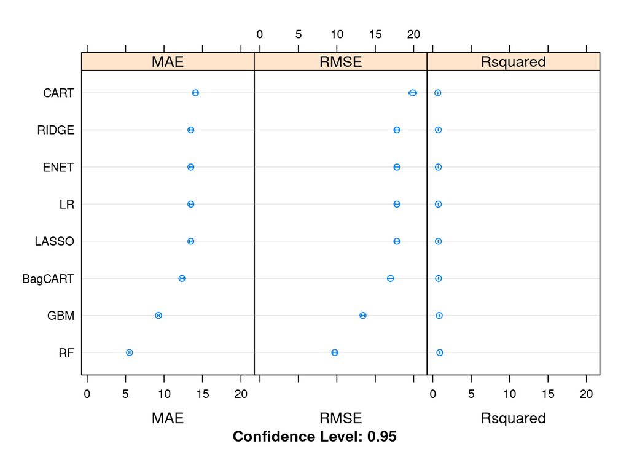

```r
dotplot(results)
```

```r
cat('The average RMSE from all models is:',
    mean(c(results$values$`LR~RMSE`,results$values$`RIDGE~RMSE`,results$values$`LASSO~RMSE`,results$values$`ENET~RMSE`,results$values$`CART~RMSE`,results$values$`BagCART~RMSE`,results$values$`RF~RMSE`,results$values$`GBM~RMSE`)),'\n')
```

```
## The average RMSE from all models is: 16.40268
```

```r
cat('Total training time for all models:',proc.time()-startModeling)
```

```
## Total training time for all models: 20612.32 94.621 20672.94 0 0
```

## 5. Improve Accuracy or Results

After we achieve a short list of machine learning algorithms with good level of accuracy, we can leverage ways to improve the accuracy of the models.

### 5.a) Algorithm Tuning

Finally, we will tune the best-performing algorithms from each group further and see whether we can get more accuracy out of them.

```r
# Tuning algorithm #1 - Random Forest
if (notifyStatus) email_notify(paste("Algorithm #1 tuning has begun!",date()))
```

```
## [1] "Java-Object{org.apache.commons.mail.SimpleEmail@3bfdc050}"
```

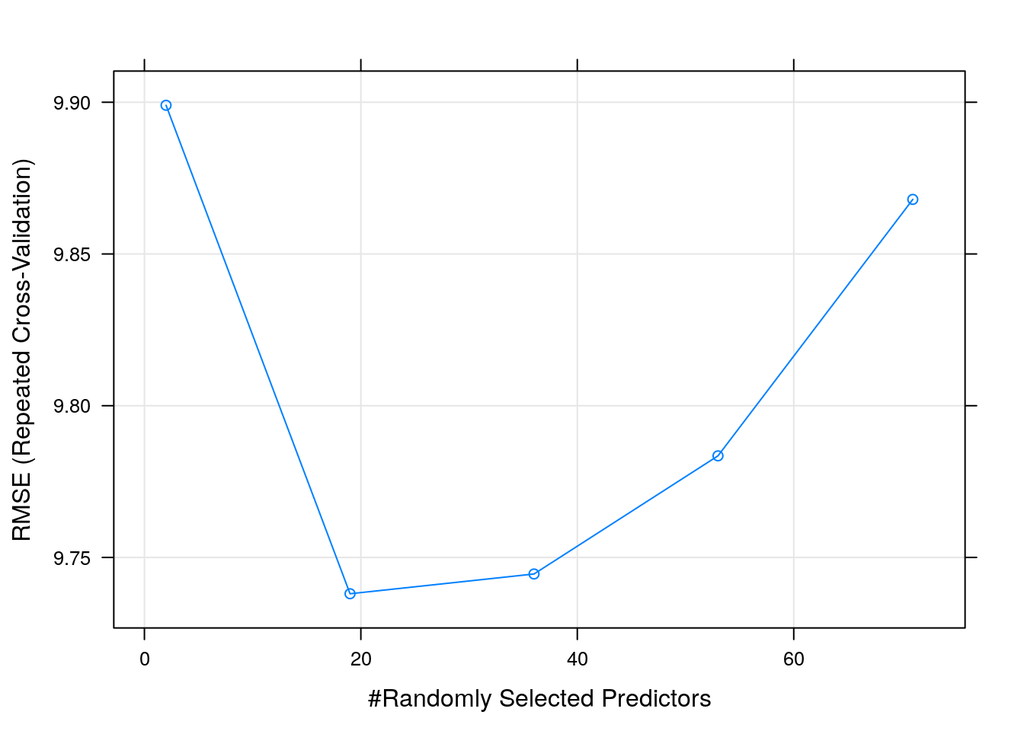

```r
startTimeModule <- proc.time()
set.seed(seedNum)
grid <- expand.grid(mtry = c(2,19,36,53,71))
fit.final1 <- train(targetVar~., data=xy_train, method="rf", metric=metricTarget, tuneGrid=grid, trControl=control)
plot(fit.final1)
```

```r
print(fit.final1)
```

```
## Random Forest
##
## 14886 samples
##    71 predictor
##
## No pre-processing
## Resampling: Cross-Validated (10 fold, repeated 1 times)
## Summary of sample sizes: 13397, 13398, 13397, 13397, 13397, 13398, ...
## Resampling results across tuning parameters:
##
##   mtry  RMSE      Rsquared   MAE
##    2    9.899000  0.9169439  5.718985
##   19    9.738031  0.9193033  5.517102
##   36    9.744545  0.9191821  5.509587
##   53    9.783477  0.9185279  5.519363
##   71    9.867985  0.9170564  5.554724
##
## RMSE was used to select the optimal model using the smallest value.
## The final value used for the model was mtry = 19.
```

```r
proc.time()-startTimeModule
```

```
##     user   system  elapsed
## 32952.93     0.00 33033.26
```

```r
if (notifyStatus) email_notify(paste("Algorithm #1 tuning completed!",date()))
```

```
## [1] "Java-Object{org.apache.commons.mail.SimpleEmail@5622fdf}"
```

```r
# Tuning algorithm #2 - Gradient Boosting
if (notifyStatus) email_notify(paste("Algorithm #2 tuning has begun!",date()))
```

```
## [1] "Java-Object{org.apache.commons.mail.SimpleEmail@4667ae56}"
```

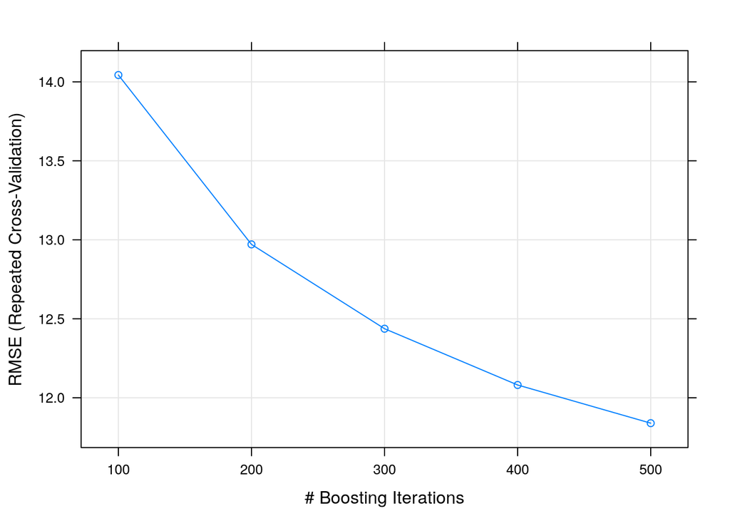

```r
startTimeModule <- proc.time()
set.seed(seedNum)
grid <- expand.grid(n.trees = c(100,200,300,400,500), interaction.depth = 3, shrinkage = 0.1, n.minobsinnode = 10)
fit.final2 <- train(targetVar~., data=xy_train, method="gbm", metric=metricTarget, tuneGrid=grid, trControl=control, verbose=F)
plot(fit.final2)
```

```r
print(fit.final2)
```

```
## Stochastic Gradient Boosting
##
## 14886 samples
##    71 predictor
##
## No pre-processing
## Resampling: Cross-Validated (10 fold, repeated 1 times)
## Summary of sample sizes: 13397, 13398, 13397, 13397, 13397, 13398, ...
## Resampling results across tuning parameters:
##
##   n.trees  RMSE      Rsquared   MAE
##   100      14.04301  0.8329095  9.814463
##   200      12.97096  0.8571009  8.931570
##   300      12.43714  0.8684606  8.457019
##   400      12.08093  0.8758260  8.146503
##   500      11.83925  0.8806919  7.927126
##
## Tuning parameter 'interaction.depth' was held constant at a value of
##  3
## Tuning parameter 'shrinkage' was held constant at a value of 0.1
##
## Tuning parameter 'n.minobsinnode' was held constant at a value of 10
## RMSE was used to select the optimal model using the smallest value.
## The final values used for the model were n.trees = 500,
##  interaction.depth = 3, shrinkage = 0.1 and n.minobsinnode = 10.
```

```r
proc.time()-startTimeModule
```

```
##    user  system elapsed
## 259.412   0.000 260.000
```

```r
if (notifyStatus) email_notify(paste("Algorithm #2 tuning completed!",date()))
```

```
## [1] "Java-Object{org.apache.commons.mail.SimpleEmail@3abbfa04}"
```

### 5.d) Compare Algorithms After Tuning

```r
results <- resamples(list(RF=fit.final1, GBM=fit.final2))
summary(results)
```

```
##
## Call:
## summary.resamples(object = results)
##
## Models: RF, GBM
## Number of resamples: 10
##
## MAE
##         Min.  1st Qu.   Median     Mean  3rd Qu.     Max. NA's
## RF  5.338967 5.452631 5.560506 5.517102 5.589363 5.615648    0
## GBM 7.826648 7.861956 7.881872 7.927126 8.000204 8.136486    0
##
## RMSE
##          Min.   1st Qu.    Median      Mean   3rd Qu.     Max. NA's
## RF   9.316082  9.489023  9.722004  9.738031  9.916933 10.45786    0
## GBM 11.323778 11.645305 11.847748 11.839250 12.031427 12.36061    0
##
## Rsquared
##          Min.   1st Qu.    Median      Mean   3rd Qu.      Max. NA's
## RF  0.9052876 0.9160520 0.9204688 0.9193033 0.9229607 0.9296302    0
## GBM 0.8714037 0.8781418 0.8817932 0.8806919 0.8851530 0.8860523    0
```

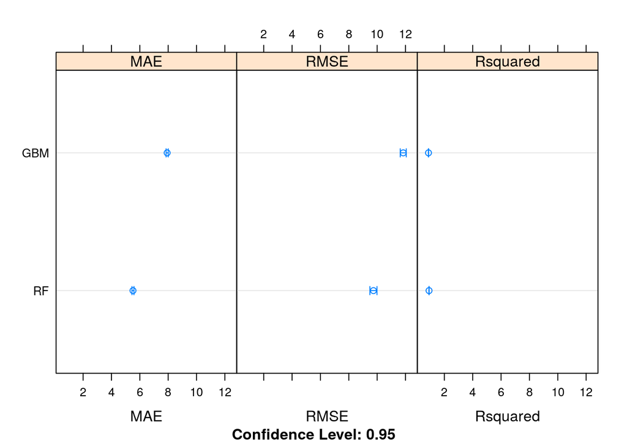

```r
dotplot(results)
```

## 6. Finalize Model and Present Results

Once we have narrow down to a model that we believe can make accurate predictions on unseen data, we are ready to finalize it. Finalizing a model may involve sub-tasks such as:

- Using an optimal model tuned to make predictions on unseen data.
- Creating a standalone model using the tuned parameters
- Saving an optimal model to file for later use.

```r
if (notifyStatus) email_notify(paste("Model Validation and Final Model Creation has begun!",date()))
```

```
## [1] "Java-Object{org.apache.commons.mail.SimpleEmail@6500df86}"
```

### 6.a) Predictions on validation dataset

```r
predictions <- predict(fit.final1, newdata=xy_test)
print(RMSE(predictions, y_test))
```

```
## [1] 9.397954
```

```r
print(R2(predictions, y_test))
```

```
## [1] 0.9253786
```

```r
predictions <- predict(fit.final2, newdata=xy_test)
print(RMSE(predictions, y_test))
```

```
## [1] 11.67491
```

```r
print(R2(predictions, y_test))
```

```
## [1] 0.8849008
```

### 6.b) Create standalone model on entire training dataset

```r
startTimeModule <- proc.time()
library(randomForest)
set.seed(seedNum)

# Combining the training and test datasets to form the original dataset that will be used for training the final model
xy_complete <- rbind(xy_train, xy_test)

# finalModel <- randomForest(targetVar~., xy_complete, mtry=19)
# summary(finalModel)
proc.time()-startTimeModule
```

```
##    user  system elapsed
##   0.036   0.000   0.037
```

### 6.c) Save model for later use

```r
#saveRDS(finalModel, "./finalModel_Regression.rds")
```

```r
if (notifyStatus) email_notify(paste("Model Validation and Final Model Creation Completed!",date()))
```

```
## [1] "Java-Object{org.apache.commons.mail.SimpleEmail@e45f292}"
```

```r
proc.time()-startTimeScript
```

```
##      user    system   elapsed
## 53968.961   184.828 54112.504
```